# GoMx Gervais’’ beaked whale habitat models: GAMs

# 1. Exploratory analysis

## 1.1 Data Inputs

NOAA SEFSC visual data goes back to 1992, but as shown in the figure below, many predictor variables are only available starting in 2003, therefore earlier visual data is currently excluded from further analyses.

Note: Future work could use monthly climatologies (averages) so that older sightings data could be used. Some dynamic drivers like eddy and front locations would not be able to be considered using that approach.

**Visual data predictor variable availability:**

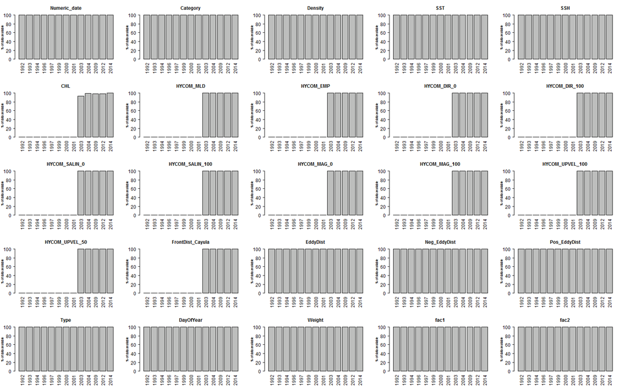

### 1.1.1 Testing and Training Sets

The data are split into training and testing sets. In this case, data from 2009 and 2013 are used for testing. Only observations post-2003 are used for modeling due to covariate limitations.

### 1.1.2 Preliminary Mapping

The visual data selected for modeling are displayed on the map below. Data from 2009 were held back for testing. Blue markers indicate HARP locations.

[interactive chart not shown]

**Acoustic Timeseries:**

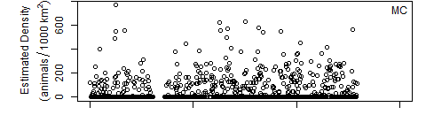

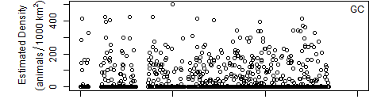

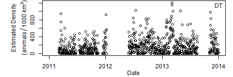

## 1.2 Examine Covariates

### Identify Outliers

Replace extreme outliers (bad data) with NaNs.

### 1.2.1 Check Covariate Distributions

Covariates have different distributions across the observations.

**Distributions of covariates from acoustic observations:**

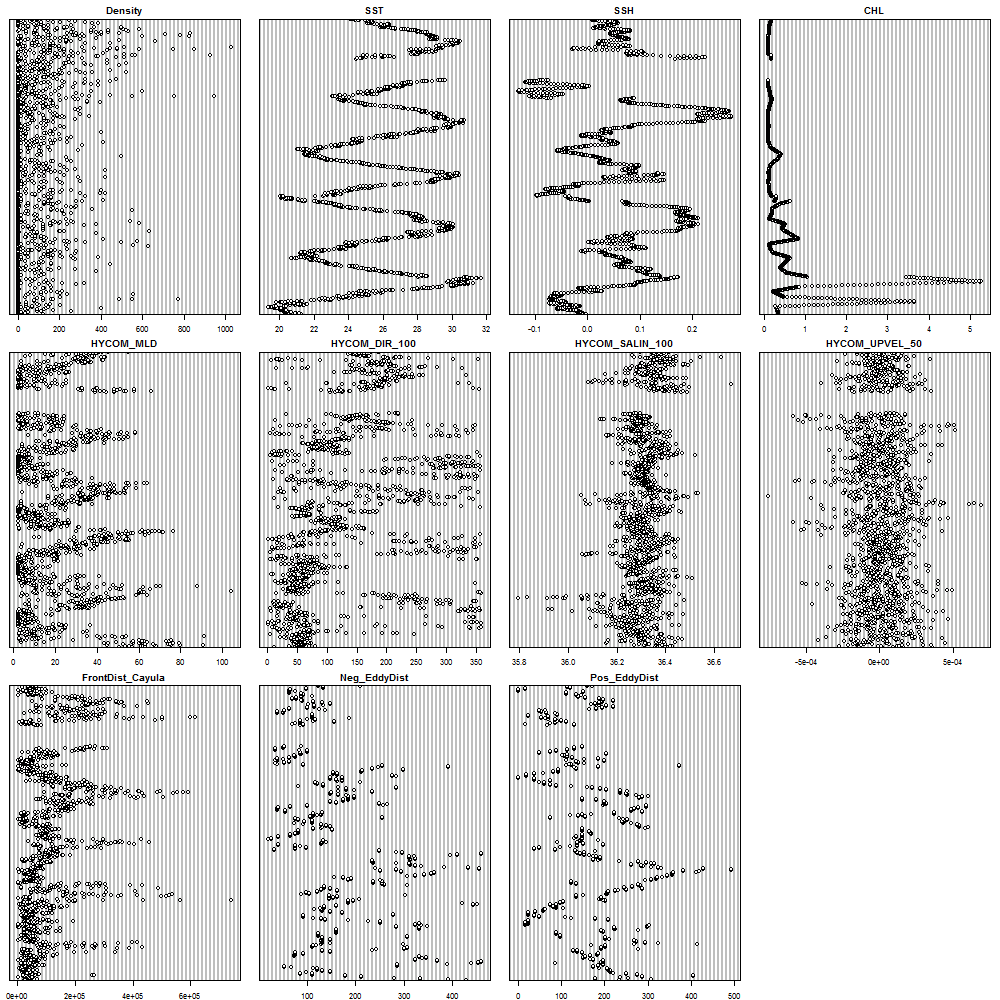

**Distributions of covariates from the visual observations:**

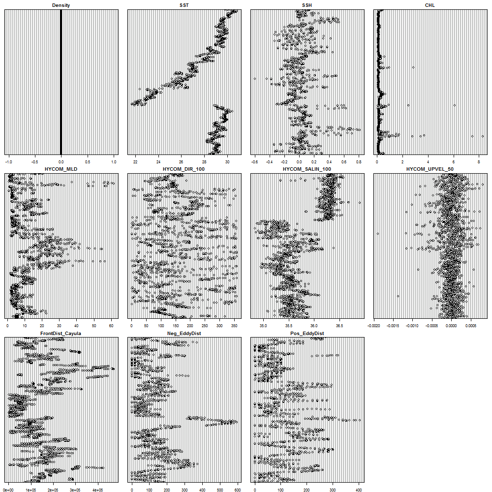

Remaining correlations are examined in the figure below. Numbers closer to 1 above the diagonal in the figure below represent correlation coefficients. Highly correlated covariates should not be used together in the same model. Day of year was excluded to avoid artifacts associated with the temporal differences of the datasets (Acoustic data are year-round, and visual data are collected in spring/summer).

**Covariate Correlations:**

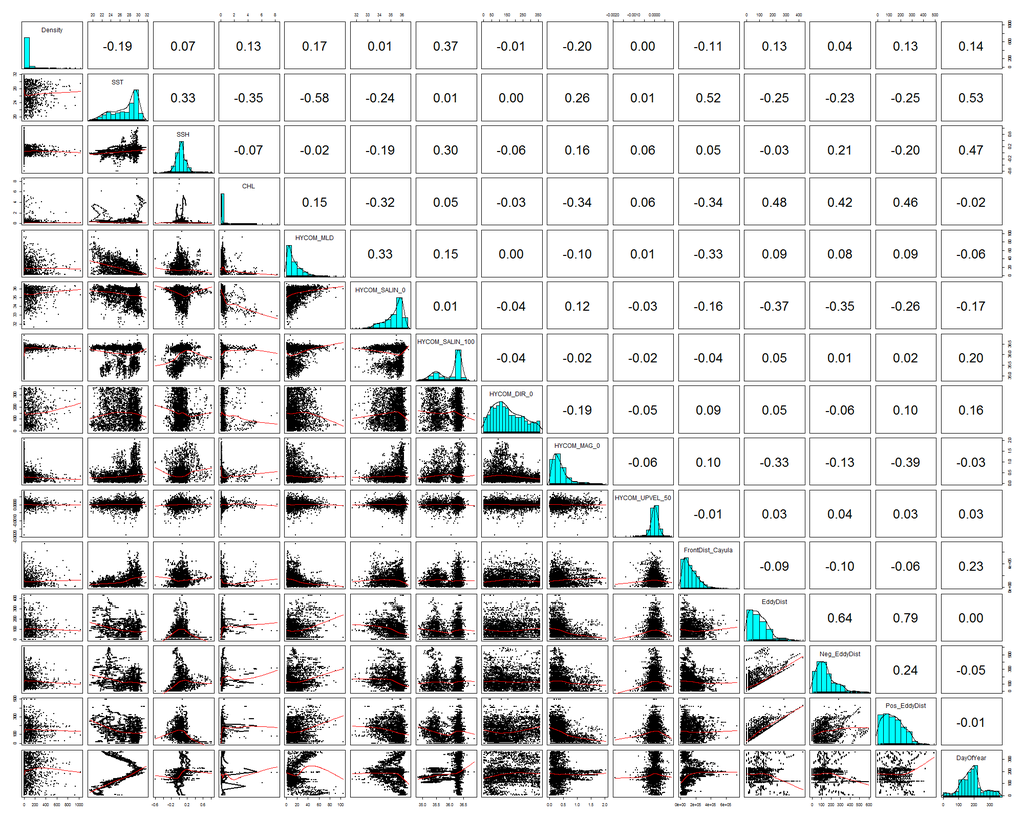

### 1.2.2 Transform Predictor Variables

Some variables, including chlorophyll, current magnitude, mixed layer depth and distance to fronts are highly skewed and were log-transformed.

Below, the two sets of covariates have been combined and transformed:

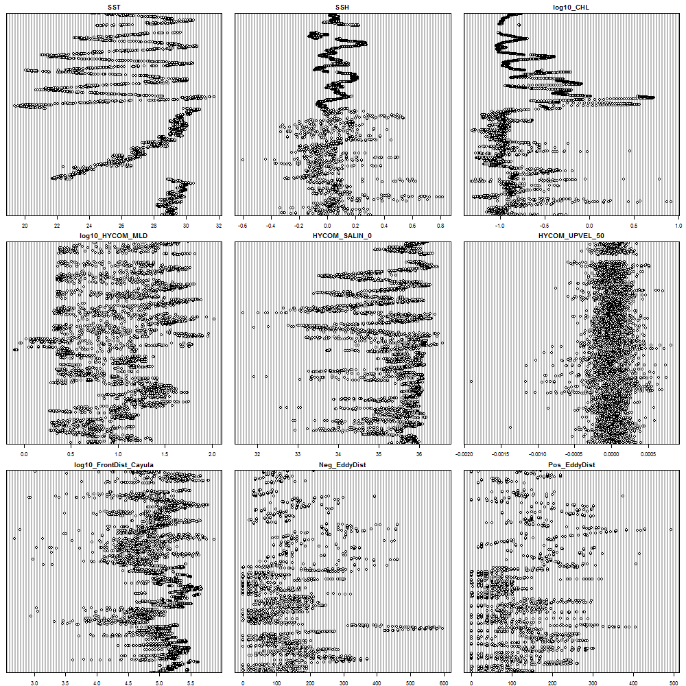

### 1.2.3 Check Predictors

To get an idea of the basic predictive power of these covariates, we can look at presence/absence relative to each variable. This also provides an opportunity to look at the range of values observed for each covariate in the visual and acoustic datasets. In the plots below dotted lines indicate the distribution of each covariate when animals were present, and solid lines indicate the distribution when animals were absent. Note that these plots do not account for effort.

**Acoustic kernel densities:**

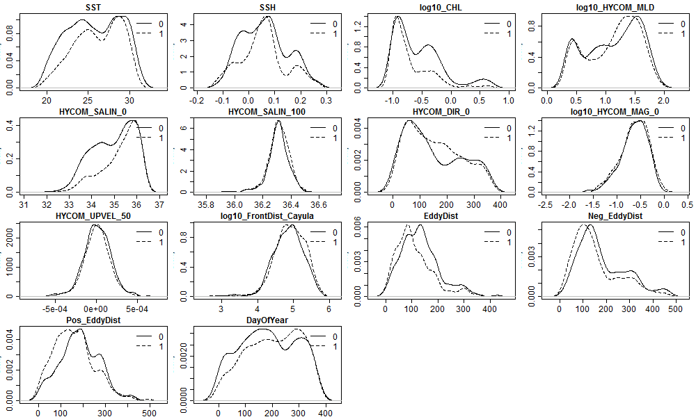

**Visual kernel densities:**

[figure not shown]

### 1.2.4 Estimate Relative Weights

To train the model, we need to know how much power the various data points have relative to one another. If an animal is sighted or heard, we know for certain that the species was present. However, if it was not heard, then it either wasn’t present, or it was present but missed. For each data type, we estimated the probability of a missed detection to downweight zeros in the presence absence data.

The visual data represent wether or not Gervais’‘beaked whale were seen during each transect segment. The probability of missing a sighting of Gervais’’ beaked whale was estimated as
$$P_{V}(detect|present) = \mu_{det} * g0\ = 0 * 0.29 = 0$$

The acoustic data represent presence or absence of Gervais’’ beaked whale detections in one day bins. Given that a group of animals is present near the sensor, the probability of detecting them in a 5 minute period is estimated at 0.65, therefore the probability of missing is 1-0.65 = 0.35. Given that animals were present, the probability of missing a group for a full day is estimated as
$$P_{A}(detect|present) = 1-(1-0.65)^{225}) \approx 1$$

Therefore we assume that there are no false negative days in the passive acoustic timeseries, and all observations are given weight = 1.

**Best visual detection probability model:**

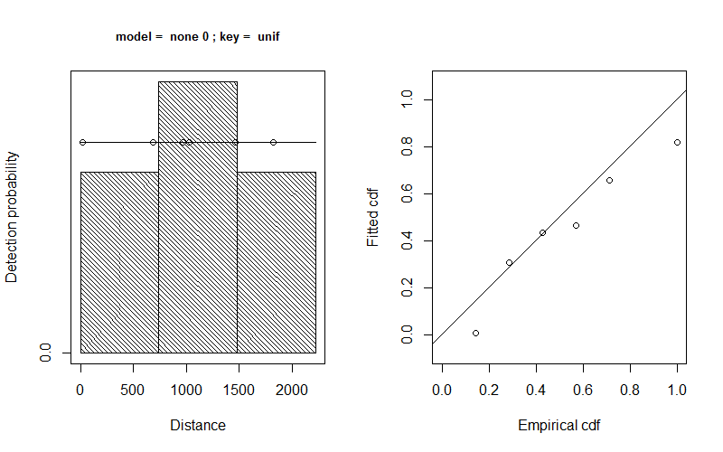

# 2. Model Fitting

Models were fit using gam from the mgcv package in R.

# 3. Model Summaries

Model summaries show that some terms were not significant.

```r
summary(best_AcOnly_model)
```

```
##
## Family: Tweedie(p=1.41)
## Link function: log
##
## Formula:
## yAcOnly ~ s(SST, bs = "ts", k = kVal) + s(SSH, bs = "ts", k = kVal) +
##     s(log10_CHL, bs = "ts", k = kVal) + s(log10_HYCOM_MLD, bs = "ts",
##     k = kVal) + s(HYCOM_SALIN_0, bs = "ts", k = kVal) + s(log10_HYCOM_MAG_0,
##     bs = "ts", k = kVal) + s(HYCOM_UPVEL_50, bs = "ts", k = kVal) +
##     s(Neg_EddyDist, bs = "ts", k = kVal) + s(Pos_EddyDist, bs = "ts",
##     k = kVal)
##
## Parametric coefficients:
##             Estimate Std. Error t value Pr(>|t|)
## (Intercept)  4.28359    0.03949   108.5   <2e-16 ***
## ---
## Signif. codes:  0 '***' 0.001 '**' 0.01 '*' 0.05 '.' 0.1 ' ' 1
##
## Approximate significance of smooth terms:
##                           edf Ref.df      F p-value
## s(SST)               1.500322      4 18.335  <2e-16 ***
## s(SSH)               0.752932      4  0.704  0.0503 .
## s(log10_CHL)         0.001819      4  0.000  0.6949
## s(log10_HYCOM_MLD)   0.001282      4  0.000  0.6342
## s(HYCOM_SALIN_0)     3.114541      4 25.719  <2e-16 ***
## s(log10_HYCOM_MAG_0) 0.001331      4  0.000  0.5903
## s(HYCOM_UPVEL_50)    0.790184      4  0.861  0.0356 *
## s(Neg_EddyDist)      0.004653      4  0.001  0.4340
## s(Pos_EddyDist)      0.007101      4  0.001  0.3913
## ---
## Signif. codes:  0 '***' 0.001 '**' 0.01 '*' 0.05 '.' 0.1 ' ' 1
##
## R-sq.(adj) =  0.0928   Deviance explained = 8.08%
## -REML = 6073.2  Scale est. = 31.554    n = 1664
```

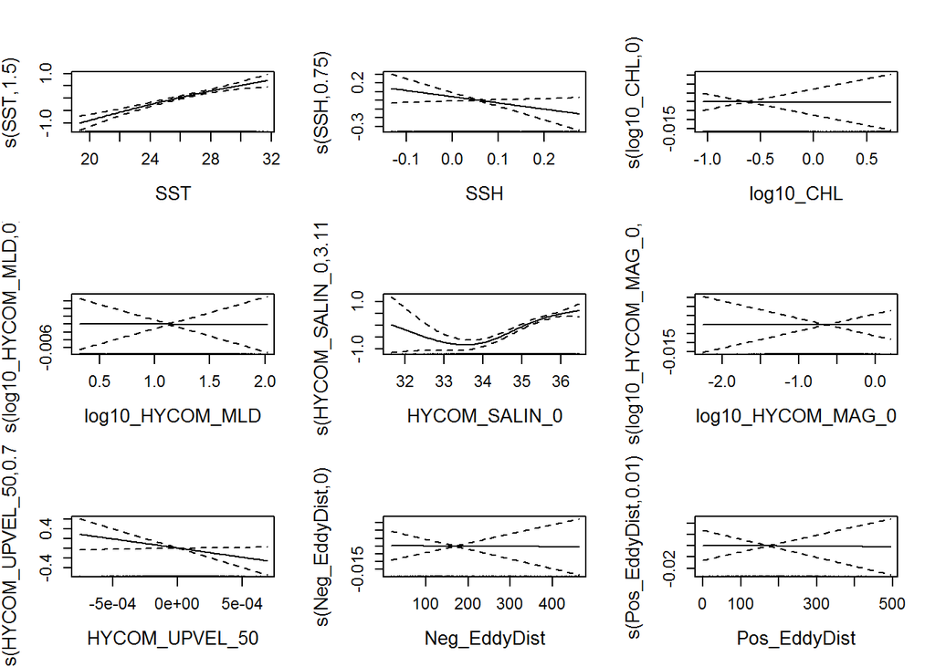

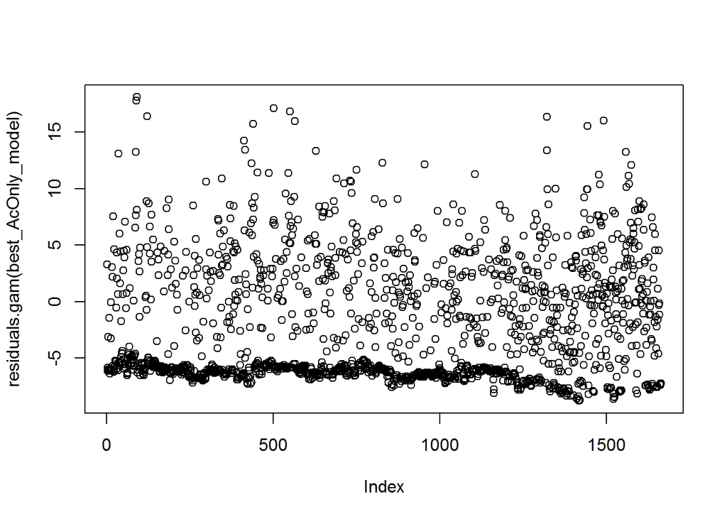

## Best Visual Only Model

```
##
## Family: Tweedie(1.3)
## Link function: log
##
## Formula:
## yVisOnly ~ s(SST, bs = "ts", k = kVal) + s(SSH, bs = "ts", k = kVal) +
##     s(log10_CHL, bs = "ts", k = kVal) + s(log10_HYCOM_MLD, bs = "ts",
##     k = kVal) + s(HYCOM_SALIN_0, bs = "ts", k = kVal) + s(log10_HYCOM_MAG_0,
##     bs = "ts", k = kVal) + s(HYCOM_UPVEL_50, bs = "ts", k = kVal) +
##     s(Neg_EddyDist, bs = "ts", k = kVal) + s(Pos_EddyDist, bs = "ts",
##     k = kVal)
##
## Parametric coefficients:
##              Estimate Std. Error t value Pr(>|t|)
## (Intercept) -42.30259    0.02282   -1854   <2e-16 ***
## ---
## Signif. codes:  0 '***' 0.001 '**' 0.01 '*' 0.05 '.' 0.1 ' ' 1
##
## Approximate significance of smooth terms:
##                            edf Ref.df F p-value
## s(SST)               2.133e-09      4 0       1
## s(SSH)               3.094e-09      4 0       1
## s(log10_CHL)         9.127e-09      4 0       1
## s(log10_HYCOM_MLD)   2.243e-09      4 0       1
## s(HYCOM_SALIN_0)     5.459e-09      4 0       1
## s(log10_HYCOM_MAG_0) 7.113e-09      4 0       1
## s(HYCOM_UPVEL_50)    8.694e-09      4 0       1
## s(Neg_EddyDist)      3.897e-09      4 0       1
## s(Pos_EddyDist)      3.290e-09      4 0       1
##
## R-sq.(adj) =    NaN   Deviance explained =  NaN%
## GCV = 4.1195e-15  Scale est. = 1.4628e-15  n = 1950
```

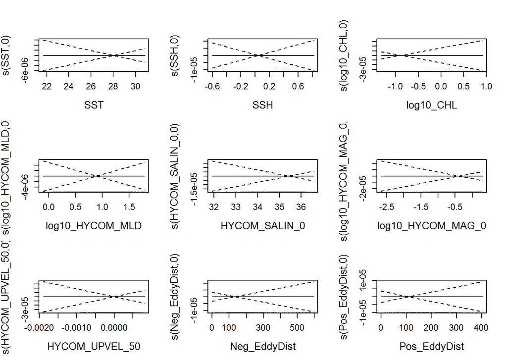

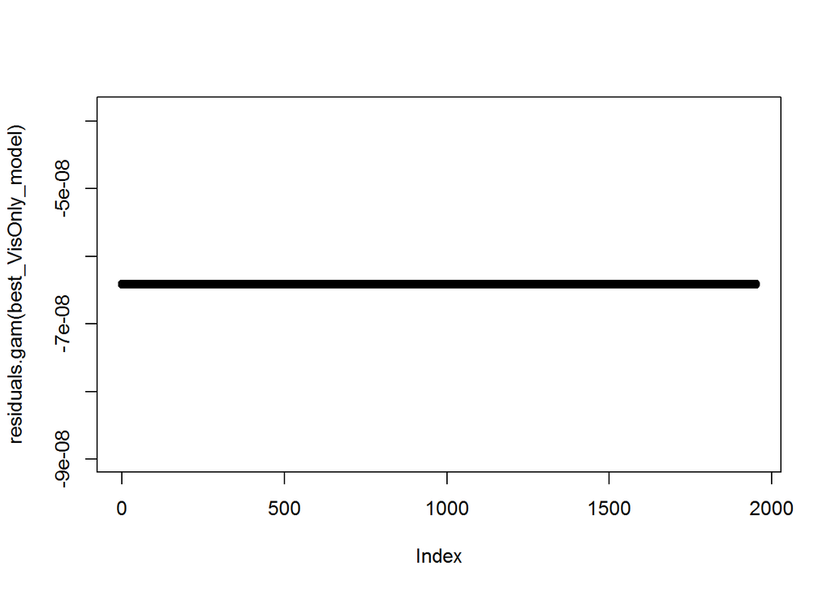

## Best Joint Visual & Acoustic Model

```
##
## Family: Tweedie(1.6)
## Link function: log
##
## Formula:
## y ~ s(SST, bs = "ts", k = kVal) + s(SSH, bs = "ts", k = kVal) +
##     s(log10_CHL, bs = "ts", k = kVal) + s(log10_HYCOM_MLD, bs = "ts",
##     k = kVal) + s(HYCOM_SALIN_0, bs = "ts", k = kVal) + s(log10_HYCOM_MAG_0,
##     bs = "ts", k = kVal) + s(HYCOM_UPVEL_50, bs = "ts", k = kVal) +
##     s(Neg_EddyDist, bs = "ts", k = kVal) + s(Pos_EddyDist, bs = "ts",
##     k = kVal)
##
## Parametric coefficients:
##             Estimate Std. Error t value Pr(>|t|)
## (Intercept)  4.52268    0.03483   129.8   <2e-16 ***
## ---
## Signif. codes:  0 '***' 0.001 '**' 0.01 '*' 0.05 '.' 0.1 ' ' 1
##
## Approximate significance of smooth terms:
##                           edf Ref.df      F  p-value
## s(SST)               3.780266      4 14.388 4.06e-13 ***
## s(SSH)               0.571761      4  0.405  0.08241 .
## s(log10_CHL)         1.787745      4  0.479  0.32773
## s(log10_HYCOM_MLD)   3.062447      4  1.890  0.04540 *
## s(HYCOM_SALIN_0)     3.588309      4 35.344  < 2e-16 ***
## s(log10_HYCOM_MAG_0) 0.001973      4  0.000  0.64999
## s(HYCOM_UPVEL_50)    1.898967      4  2.680  0.00214 **
## s(Neg_EddyDist)      0.048238      4  0.014  0.27898
## s(Pos_EddyDist)      2.711145      4  1.112  0.15818
## ---
## Signif. codes:  0 '***' 0.001 '**' 0.01 '*' 0.05 '.' 0.1 ' ' 1
##
## R-sq.(adj) =  0.101   Deviance explained = 6.99%
## GCV = 8.4683  Scale est. = 7.0478    n = 3614
```

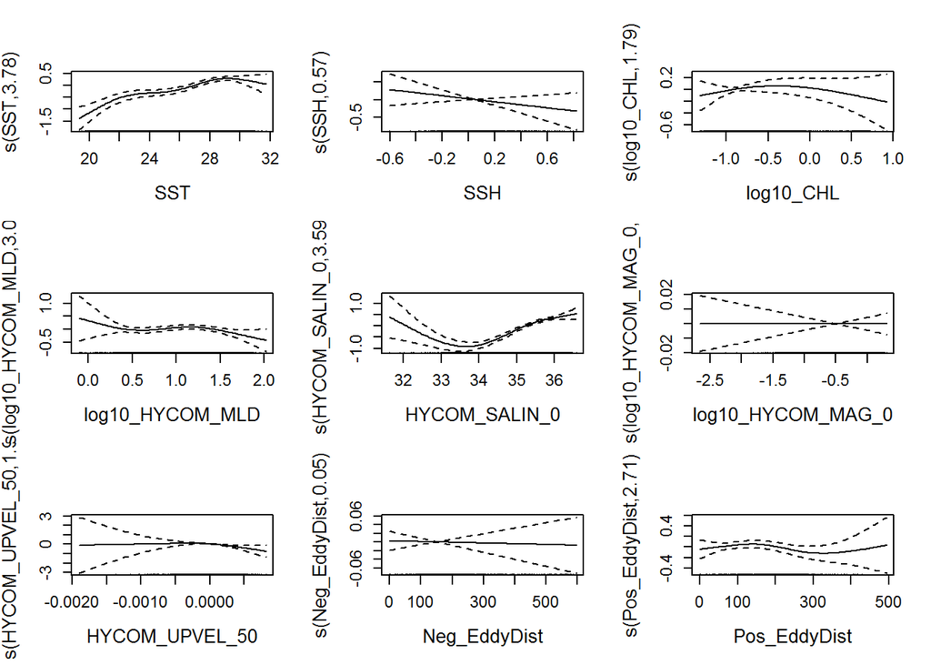

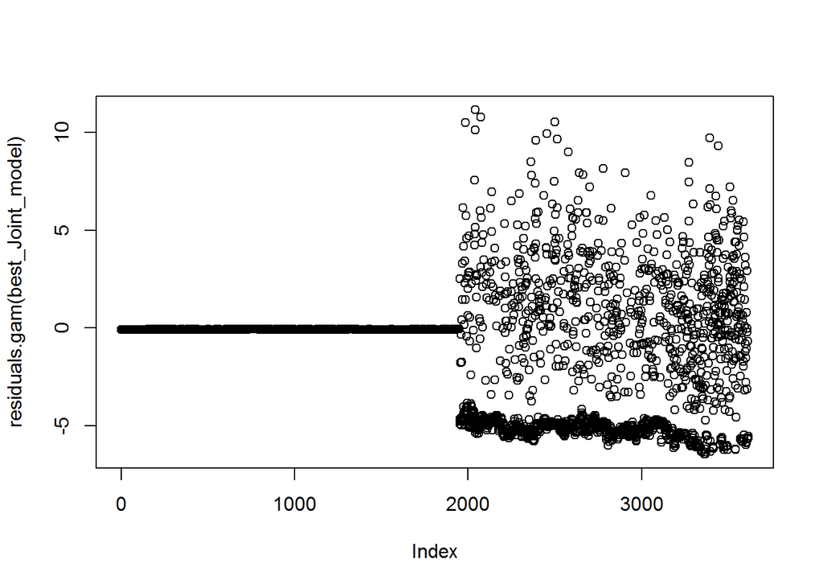

# 4. Predict on Test Data

## 4.1 Temporal prediction

### 4.1.1 Acoustic Only Prediction

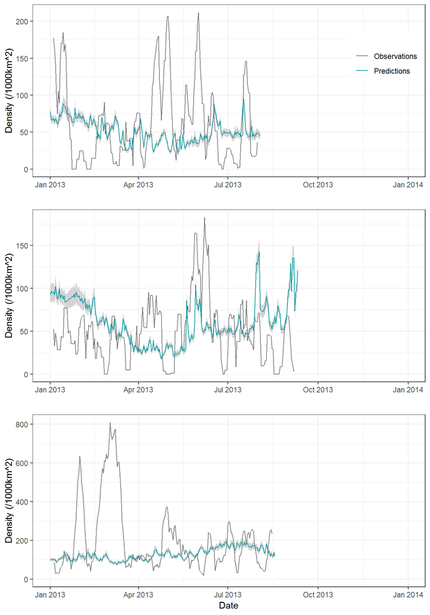

### 4.1.2 Visual Only Prediction

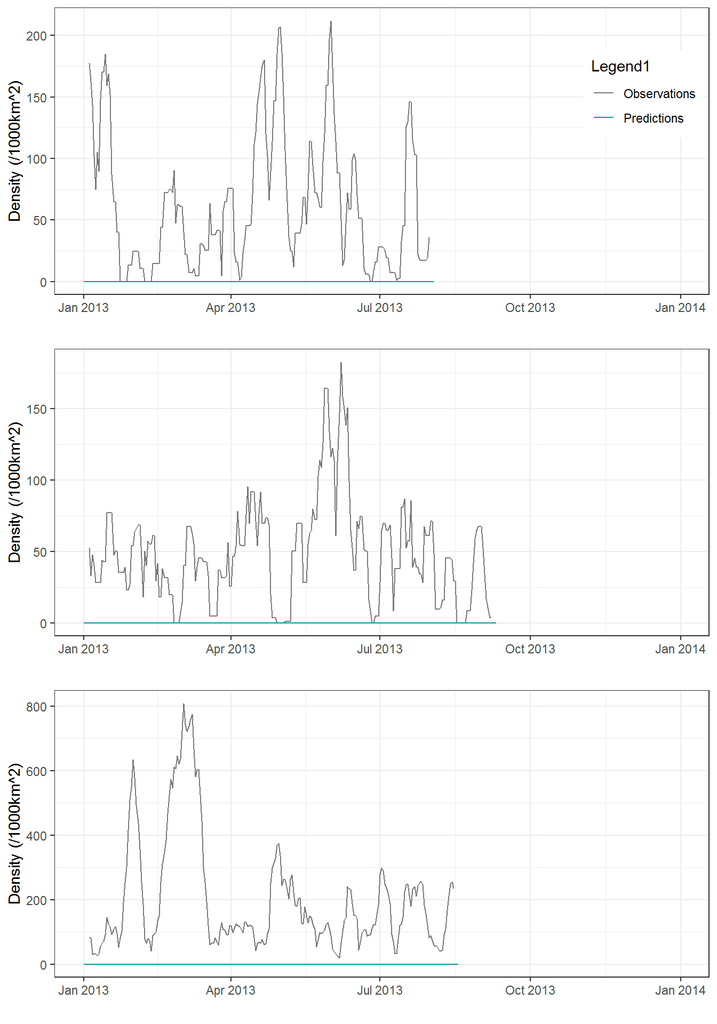

### 4.1.3 Joint Prediction

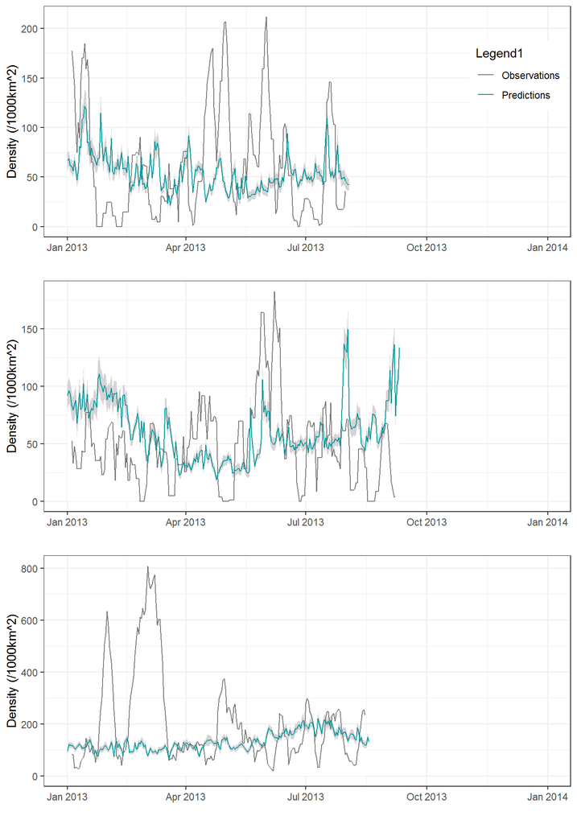

## 4.2 Spatial Prediction

Models were evaluated for summer (July 2009) and winter(January 2009) across the entire Gulf of Mexico (US EEZ beyond the 200m contour).

### Model averaging

Alternatively, the visual and acoustic models could be averaged.

**Summer 2009 predicted distribution and test sightings:**

[interactive chart not shown]

**Winter 2009 predicted distribution:**

[interactive chart not shown]

# 5. Monthly model predictions

Spatial model predictions were generated using oceanographic variables averaged by month between 2003 and 2015.

[interactive chart not shown]